# A3: Incarceration

### Introduction

This data analysis will focus on the number of incarcerated Black people around the United States, whether they are in prison or in jail. Over the last decade, the Black Lives Matter (BLM) movement has gained quite the following, but the ideas backing this movement are not new. Many people around the country have been continuously fighting for equality and equity for Black people and other people of color. Some of the most famous stories often have to do with the mistreatment Black people have had from the justice system, whether that is regarding police brutality or racism during courthouse trials. Battling the systemic racism in this country is not a small matter, but using data analysis can be a significant help. Therefore, this project will be focused on finding areas of the country where Black people are incarcerated the most. The year 2013 will be focused on often, as it is the most recent year in the dataset without significantly large amounts of unavailable data. However, when possible, the year 2018 will be used, as it is the most recent. Analyzing this data during more recent years can provide a better idea of the issue today, in 2023, while looking at a larger time span can be informative of the history of how we have gotten to today.

### Summary Information

The following findings provide a general idea on the numbers of Black people in prison and jail during 2013. The average value of Black prison population in 2013 across all counties was 280.9422646. The location with the highest Black prison population was Cook County, IL with a value of 18152. For jails in 2013, the average Black jail population across all counties was 87.9441323. The location with the highest value of 7229.97 was also Cook County, IL. These values show that on average, there are more Black people in prison than jail in 2013. Interestingly, the highest jail and prison count for Black people in 2013 was in the same location, suggesting that incarceration of Black people in this area was perhaps unusually high.

### The Dataset

This data was collected by a nonprofit research and policy organization, the Vera Institute of Justice. Two Bureau of Justice Statistics data collections were used to create the datasets used in this analysis: the Census of Jails and the Annual Survey of Jails. The data is often updated as Vera accesses newly released data. Vera collected this data because incarceration research is often focused on a state-level basis, and they wanted to make the data more appropriate for county-level analysis. This, in turn, can help provide enough information to create more accurate claims on incarceration in the U.S. as a whole. The dataset about prison population per county and state has 36 features and 153811 observations. The dataset about jail population per county and state has 28 features and 153811 observations. Both of these datasets have limitations, however, because there are a lot of missing data points, whether that is over certain years or for specific counties. These limitations can be shown in some of the graphs below, as there are gaps in the visualizations. However, working with this data gives a lot of opportunity for reflection on the incarceration and justice systems in the United States. This analysis and the following graphs bring up many different questions regarding the reasoning behind high or low incarceration rates in certain areas of the country. While this analysis cannot make claims on the reasoning behind the numbers, as it does not provide context of why these people were put in jail or prison, it allows for more questions to be raised concerning the patterns and correlations in the data.

### Trends Over Time Chart: Black Prison Population, 2003-2013

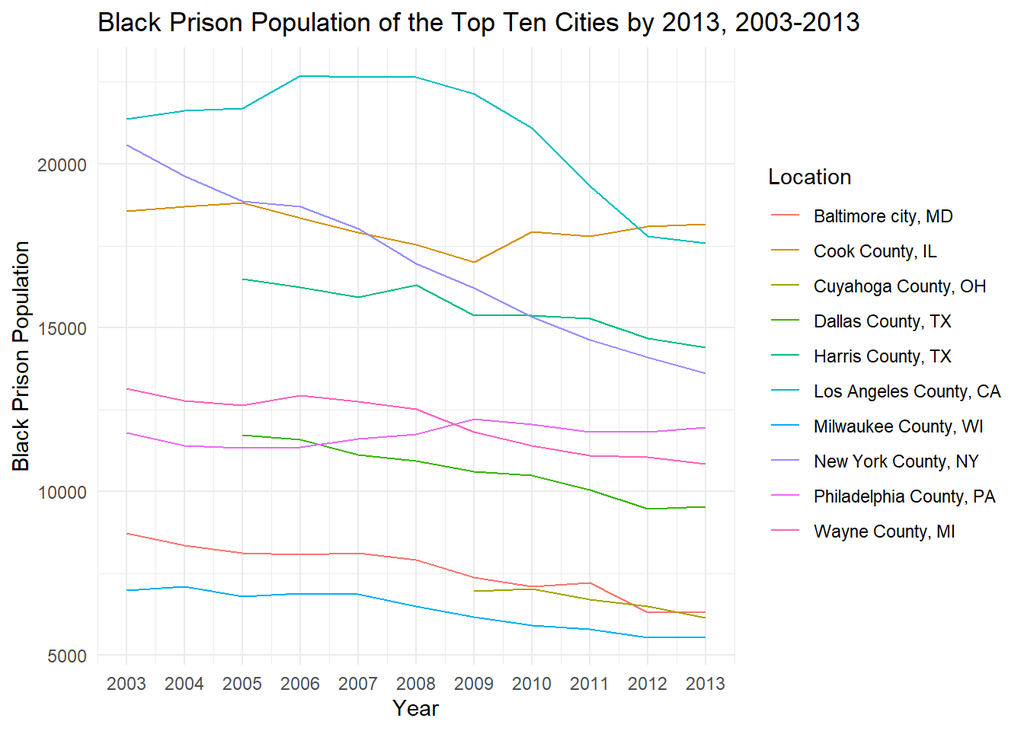

### Variable Comparison Chart: Black Prison and Jail Populations by Total Prison and Jail Populations, 1970-2018

This next chart is a combination of two graphs: one for the Black prison population and one for the Black jail population in Cook County, Illinois, as it has been established that this county has had large numbers of Black people in both jail and prison. These graphs compares the total prison and jail populations to the number of Black people in prison and jail from 1970 to 2018, the span of the data set. It is clear that there is a positive slope in both graphs, meaning as more people in general are incarcerated, more Black people are also incarcerated, which is a logical piece of insight. Additionally, it is clearly shown that there are more people in prison than jail. However, putting these two graphs together, it is apparent that the jail and prison rates in this county have a very similar trajectories. Therefore, it would be interesting for future data analysis projects to see if there is any cause and effect between the numbers of people in jail and in prison.

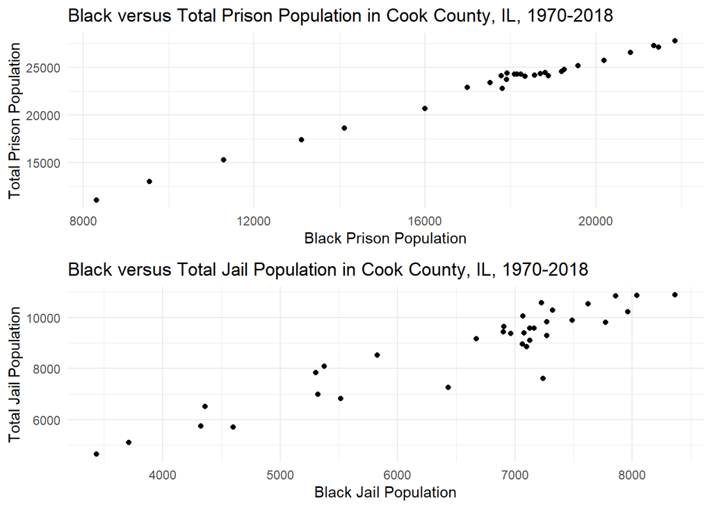

### Map: Average Black Jail Population, 2018

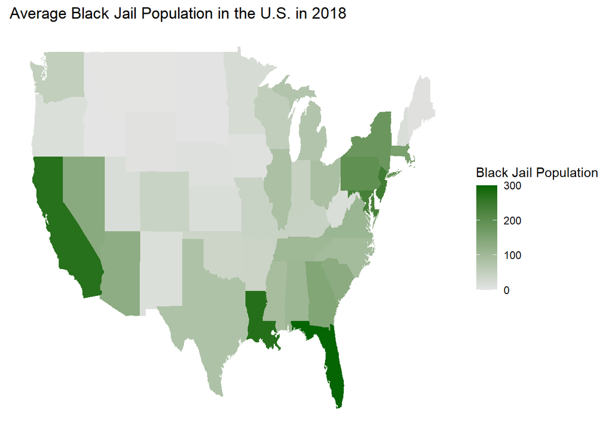